# Top 1000 Movies According to IMDB Users

Casey Freimund

```r
library(knitr)
library(ggplot2)
library(fitdistrplus)
```

## Finding The Data

```r
#DATA LOADER
#A function that takes in an empty vector and reads in the html files that contain data on the top 1000 movies on IMDB. It then combines them into one character vector and outputs that vector, 'movies'
#v = empty vector
html_loader=function(v){
  imdb50=readLines("imdb50.html")
  imdb100=readLines("imdb100.html")
  imdb150=readLines("imdb150.html")
  imdb200=readLines("imdb200.html")
  imdb250=readLines("imdb250.html")
  imdb300=readLines("imdb300.html")
  imdb350=readLines("imdb350.html")
  imdb400=readLines("imdb400.html")
  imdb450=readLines("imdb450.html")
  imdb500=readLines("imdb500.html")
  imdb550=readLines("imdb550.html")
  imdb600=readLines("imdb600.html")
  imdb650=readLines("imdb650.html")
  imdb700=readLines("imdb700.html")
  imdb750=readLines("imdb750.html")
  imdb800=readLines("imdb800.html")
  imdb850=readLines("imdb850.html")
  imdb900=readLines("imdb900.html")
  imdb950=readLines("imdb950.html")
  imdb1000=readLines("imdb1000.html")

  movies=c(imdb50,imdb100,imdb150,imdb200,imdb250,imdb300,imdb350,imdb400,imdb450,imdb500,imdb550,imdb600,imdb650,imdb700,imdb750,imdb800,imdb850,imdb900,imdb950,imdb1000)

  return(movies)
}
```

```r
#TITLE FINDER
#A Function that takes in a character string and searches for a pattern that contains the movie title. It then 'gets rid' of any unnecessary symbols and/or punctuations that don't pertain to the movie and outputs a vector that contains the movie titles, 'titles'.
#char.v = character string
title.finder=function(char.v){

  title.pattern=">\\s+<img\\s+alt.*"
  start.pat="([0-9]|[A-Z])"
  stop.pat="\"$"

  title.junk=regmatches(char.v,regexpr(title.pattern,char.v))
  titles=substr(title.junk,start = regexpr(start.pat,title.junk),stop = regexpr(stop.pat,title.junk)-1)
  titles=titles[titles!=""]
  return(titles)
}
```

```r
#GENRE FINDER
#A funtion that takes in a character string and searches for a pattern that contains the movies' genre(s). It then 'gets rid' of any unnecessary symbols and/or punctuations that don't pertain to the movie genre(s) and outputs a vector that contains the movie genres, 'genre'.
#char.v = character string
genre.finder=function(char.v){

  genre.pattern="[A-Z].*\\s+</span>"
  start.pat="[A-Z]"
  stop.pat="[a-z]\\s+</span>"

  genre.junk=regmatches(char.v,regexpr(genre.pattern,char.v))
  genre=substr(genre.junk,start = regexpr(start.pat,genre.junk),stop = regexpr(stop.pat,genre.junk))

  return(genre)
}
```

```r
#ACTOR FINDER
#A funtion that takes in a character string and searches for the location of the top 4 actors/actresses. It then 'gets rid' of any unnecessary symbols and/or punctuations that don't pertain to their names and outputs a vector that contains the top 4 paid actors and actresses from each movie, 'actor'.
#char.v = character string
actor.finder=function(char.v){

  actors.pattern="Stars:"
  stars.loc=grep(actors.pattern,char.v)

  a1.loc=stars.loc+2
  a2.loc=stars.loc+4
  a3.loc=stars.loc+6
  a4.loc=stars.loc+8

  a1=char.v[a1.loc]
  a2=char.v[a2.loc]
  a3=char.v[a3.loc]
  a4=char.v[a4.loc]

  stop.pat="</a>"

  a1=substr(a1,start = 2,stop = regexpr(stop.pat,a1)-1)
  a2=substr(a2,start = 2,stop = regexpr(stop.pat,a2)-1)
  a3=substr(a3,start = 2,stop = regexpr(stop.pat,a3)-1)
  a4=substr(a4,start = 2,stop = regexpr(stop.pat,a4)-1)

  actor=paste(a1,a2,a3,a4,sep = ", ")

  return(actor)
}
```

```r
#REVENUE FINDER
#A funtion that takes in a character string and searches for the location of the gross US revenue of a movie. It then 'gets rid' of any unnecessary symbols and/or punctuations that don't pertain to the gross US revenue and outputs a vector that contains the the gross US revenue for each movie, 'rev'. If gross US revenue isn't listed, gross revenue becomes NA.
#char.v = character string
rev.finder=function(char.v){

  rev.pat="Votes:"
  rev.loc=grep(rev.pat,char.v)
  rev.loc=rev.loc+3
  rev=char.v[rev.loc]
  rev=substr(rev,start = regexpr("\\$[0-9]",rev)+1,stop = regexpr("M",rev)-1)
  rev=as.numeric(rev)
  return(rev)
}
```

```r
#RELEASE DATE FINDER
#A funtion that takes in a character string and searches for the location of the year when the movie was released. It then gets rid of any unnecessary symbols and/or punctuations and outputs a vector that contains the year in which the movie was released, 'date'.
#char.v = character string
year.finder=function(char.v){

  date.pat="lister-item-year.*[0-9]{4}"
  date.junk=regmatches(char.v,regexpr(date.pat,char.v))
  date=substr(date.junk,start = regexpr("[0-9]",date.junk),stop = length(date.junk))
  date=as.numeric(date)

  return(date)
}
```

```r
#RATING/VOTES FINDER
#A funtion that takes in a character string and searches for the location of the rating/voting statistics. It then isolates the average rating into 1 variable, 'rates', and the total number of votes, 'votes', into another variable. Then it gets rid of any unnecessary symbols and/or punctuations and outputs a list of 2 vectors that contain the average rating by IMDB users `$rating` and the total number of votes `$votes`.
#char.v = character string
vote.finder=function(char.v){

  vote.pat="Users rated.*votes"
  vote.junk=regmatches(char.v,regexpr(vote.pat,char.v))

  rate=substr(vote.junk,start = regexpr("[0-9]",vote.junk),stop = regexpr("[0-9]/[0-9]{2}",vote.junk))
  rate=as.numeric(rate)

  votes=substr(vote.junk,start = regexpr("\\([0-9]",vote.junk)+1,stop = regexpr("\\svotes",vote.junk))
  votes=gsub("(\\,)+","",votes)
  votes=as.numeric(votes)

 return(list(rating=rate,votes=votes))
}
```

```r
#INFO FINDER
#A function that takes in a character string and searches for the rating, total votes, title, year released, genre, top 4 paid actors, and gross US revenue for a list of movies and outputs a chart of the previously stated categories.
#v = character string
info.finder=function(v){

  Rating=vote.finder(v)$rating
  Total_Votes=vote.finder(v)$votes
  Title=title.finder(v)
  Year=year.finder(v)
  Genre=genre.finder(v)
  Actors=actor.finder(v)
  Revenue=rev.finder(v)

  movie.chart=cbind.data.frame(Rating,Total_Votes,Title,Year,Genre,Actors,Revenue)

  movie.chart$Title=as.character(movie.chart$Title)
  movie.chart$Genre=as.character(movie.chart$Genre)
  movie.chart$Actors=as.character(movie.chart$Actors)

  return(movie.chart)
}
```

```r
#Reads in the movie text for the top 1000 movies and puts the relevant information into a dataframe called 'movies'
movie.text=0
movie.text=html_loader(movie.text)
movies=info.finder(movie.text)
```

```r
#Checks that data aligns properly by printing the first 5 and last 5 movies
kable(movies[1:5,],caption = "Movies #1-5")
```

Movies #1-5

| Rating | Total_Votes | Title | Year | Genre | Actors | Revenue |
| --- | --- | --- | --- | --- | --- | --- |
| 9.3 | 2061970 | The Shawshank Redemption | 1994 | Drama | Tim Robbins, Morgan Freeman, Bob Gunton, William Sadler | 28.34 |
| 9.2 | 1414562 | The Godfather | 1972 | Crime, Drama | Marlon Brando, Al Pacino, James Caan, Diane Keaton | 134.97 |
| 9.0 | 2028211 | The Dark Knight | 2008 | Action, Crime, Drama | Christian Bale, Heath Ledger, Aaron Eckhart, Michael Caine | 534.86 |
| 9.0 | 981305 | The Godfather: Part II | 1974 | Crime, Drama | Al Pacino, Robert De Niro, Robert Duvall, Diane Keaton | 57.30 |
| 8.9 | 1468152 | The Lord of the Rings: The Return of the King | 2003 | Adventure, Drama, Fantasy | Elijah Wood, Viggo Mortensen, Ian McKellen, Orlando Bloom | 377.85 |

```r
kable(movies[996:1000,],caption = "Movies #996-1000")
```

Movies #996-1000

|  | Rating | Total_Votes | Title | Year | Genre | Actors | Revenue |
| --- | --- | --- | --- | --- | --- | --- | --- |
| 996 | 7.5 | 332546 | Collateral | 2004 | Crime, Drama, Thriller | Tom Cruise, Jamie Foxx, Jada Pinkett Smith, Mark Ruffalo | 101.01 |
| 997 | 7.5 | 395231 | Ice Age | 2002 | Animation, Adventure, Comedy | Denis Leary, John Leguizamo, Ray Romano, Goran Visnjic | 176.39 |
| 998 | 7.5 | 367291 | Gangs of New York | 2002 | Crime, Drama | Leonardo DiCaprio, Cameron Diaz, Daniel Day-Lewis, Jim Broadbent | 77.81 |
| 999 | 7.5 | 309201 | Batman | 1989 | Action, Adventure | Michael Keaton, Jack Nicholson, Kim Basinger, Robert Wuhl | 251.19 |
| 1000 | 7.5 | 142584 | The Fly | 1986 | Drama, Horror, Sci-Fi | Jeff Goldblum, Geena Davis, John Getz, Joy Boushel | 40.46 |

## Probability Distributions for Numerical Data

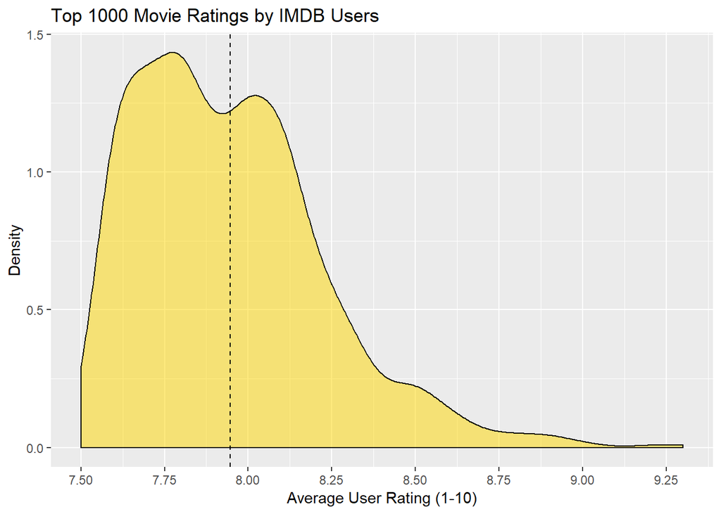

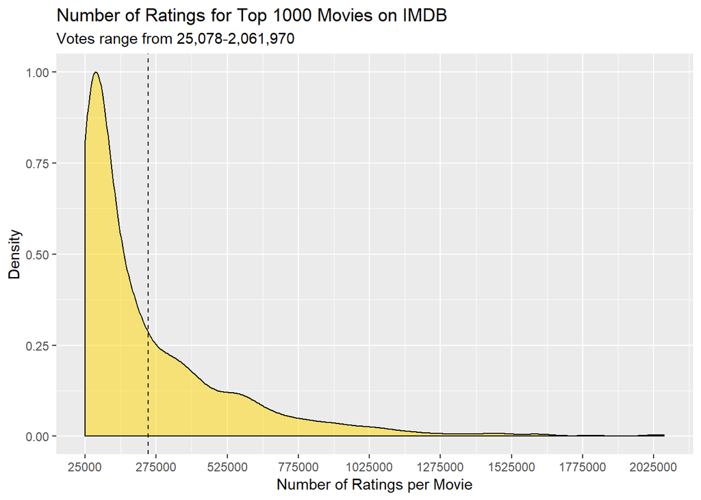

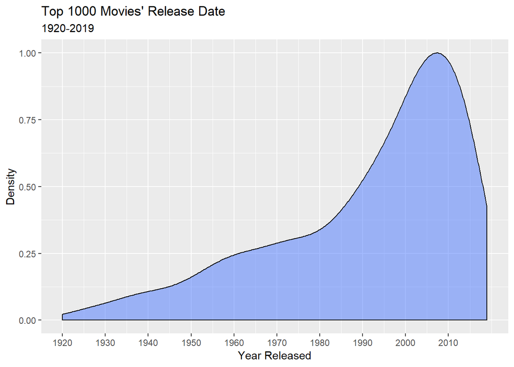

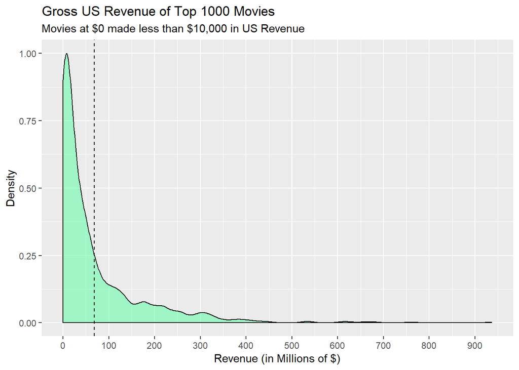

## Distribution Fitting to Numerical Data

#### Revenue

When fitting the exponential and log-normal distribution to the revenue data, I opted to omit the movies that didn’t have a gross US revenue reported. If I were to insert values in place of the NA values, it would have skewed my distributions with parameters that truly didn’t reflect the data set. When I was fitting the log-normal distribution to the revenue data, I had to omit values that were equal to 0, because log(0) is undefined and if I were to input a small decimal equal to about 0, 0.000001 for example, the log of my small decimal value would result in large negative numbers and potentially skew my parameter estimates.

##### -Exponential Distribution

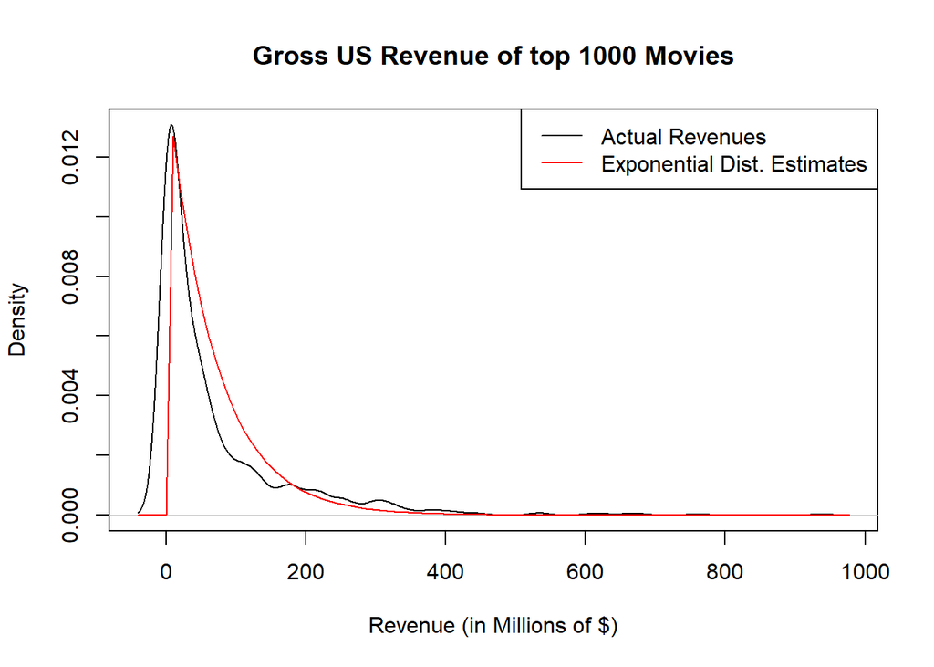

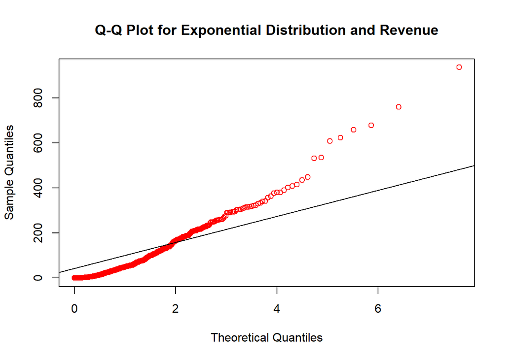

```
##
##  One-sample Kolmogorov-Smirnov test
##
## data:  movies$Revenue
## D = 0.21355, p-value < 2.2e-16
## alternative hypothesis: two-sided
```